# 📊 Rapport d’Analyse : Performance Supermarché

Groupe_13

2026-01-14

# 1. PRÉPARATION DE L’ENVIRONNEMENT

## a. Packages et librairies nécessaires

Nous utilisons une suite de packages pour la manipulation de données, la visualisation et la mise en forme de rapports professionnels.

```r
# Liste des packages nécessaires
packages <- c("tidyverse", "DT", "lubridate", "kableExtra", "scales")
installed_packages <- packages %in% rownames(installed.packages())
if (any(installed_packages == FALSE)) {
  install.packages(packages[!installed_packages])
}

# Chargement des librairies
library(tidyverse)  # Manipulation et visualisation (ggplot2)
library(DT)         # Tableaux interactifs
library(lubridate)  # Gestion des dates
library(kableExtra) # Mise en forme des tableaux
library(scales)     # Formatage des nombres et monnaies
```

## b. Chargement du dataset

Chargement des données sources et premier aperçu des transactions.

```r
df <- read.csv("SuperMarket Analysis.csv", check.names = FALSE)

# Affichage interactif des 10 premières lignes
datatable(head(df, 10), options = list(scrollX = TRUE))
```

|  | Invoice ID | Branch | City | Customer type | Gender | Product line | Unit price | Quantity | Tax 5% | Sales | Date | Time | Payment | cogs | gross margin percentage | gross income | Rating |
| --- | --- | --- | --- | --- | --- | --- | --- | --- | --- | --- | --- | --- | --- | --- | --- | --- | --- |
| 1 | 750-67-8428 | Alex | Yangon | Member | Female | Health and beauty | 74.69 | 7 | 26.1415 | 548.9715 | 1/5/2019 | 1:08:00 PM | Ewallet | 522.83 | 4.761904762 | 26.1415 | 9.1 |
| 2 | 226-31-3081 | Giza | Naypyitaw | Normal | Female | Electronic accessories | 15.28 | 5 | 3.82 | 80.22 | 3/8/2019 | 10:29:00 AM | Cash | 76.4 | 4.761904762 | 3.82 | 9.6 |
| 3 | 631-41-3108 | Alex | Yangon | Normal | Female | Home and lifestyle | 46.33 | 7 | 16.2155 | 340.5255 | 3/3/2019 | 1:23:00 PM | Credit card | 324.31 | 4.761904762 | 16.2155 | 7.4 |
| 4 | 123-19-1176 | Alex | Yangon | Member | Female | Health and beauty | 58.22 | 8 | 23.288 | 489.048 | 1/27/2019 | 8:33:00 PM | Ewallet | 465.76 | 4.761904762 | 23.288 | 8.4 |
| 5 | 373-73-7910 | Alex | Yangon | Member | Female | Sports and travel | 86.31 | 7 | 30.2085 | 634.3785 | 2/8/2019 | 10:37:00 AM | Ewallet | 604.17 | 4.761904762 | 30.2085 | 5.3 |
| 6 | 699-14-3026 | Giza | Naypyitaw | Member | Female | Electronic accessories | 85.39 | 7 | 29.8865 | 627.6165 | 3/25/2019 | 6:30:00 PM | Ewallet | 597.73 | 4.761904762 | 29.8865 | 4.1 |
| 7 | 355-53-5943 | Alex | Yangon | Member | Female | Electronic accessories | 68.84 | 6 | 20.652 | 433.692 | 2/25/2019 | 2:36:00 PM | Ewallet | 413.04 | 4.761904762 | 20.652 | 5.8 |
| 8 | 315-22-5665 | Giza | Naypyitaw | Member | Female | Home and lifestyle | 73.56 | 10 | 36.78 | 772.38 | 2/24/2019 | 11:38:00 AM | Ewallet | 735.6 | 4.761904762 | 36.78 | 8 |
| 9 | 665-32-9167 | Alex | Yangon | Member | Female | Health and beauty | 36.26 | 2 | 3.626 | 76.146 | 1/10/2019 | 5:15:00 PM | Credit card | 72.52 | 4.761904762 | 3.626 | 7.2 |
| 10 | 692-92-5582 | Cairo | Mandalay | Member | Female | Food and beverages | 54.84 | 3 | 8.226 | 172.746 | 2/20/2019 | 1:27:00 PM | Credit card | 164.52 | 4.761904762 | 8.226 | 5.9 |

# 2. NETTOYAGE ET PRÉPARATION DES DONNÉES

Cette étape garantit l’intégrité des calculs en gérant les types de données et en supprimant les bruits inutiles.

```r
# a. Suppression de l'ID facture (non utile pour l'analyse statistique)
df_clean <- df %>% select(-`Invoice ID`)

# b. Audit de qualité : Valeurs manquantes et doublons
qualite <- data.frame(
  Indicateur = c("Valeurs manquantes", "Doublons"),
  Total = c(sum(is.na(df_clean)), sum(duplicated(df_clean)))
)

kable(qualite) %>% kable_styling(full_width = F, position = "left")
```

| Indicateur | Total |
| --- | --- |
| Valeurs manquantes | 0 |
| Doublons | 0 |

```r
# c. Conversion des types
df_clean <- df_clean %>%
  mutate(
    Date = as.Date(Date, format="%m/%d/%Y"),
    across(where(is.character), as.factor)
  )
```

# 3. ANALYSE DES PERFORMANCES PRODUITS

## A. Identification des catégories leaders

Nous comparons ici le volume de vente, le Chiffre d’Affaires et la satisfaction client.

```r
product_sales <- df_clean %>%
  group_by(`Product line`) %>%
  summarise(
    Quantite_Totale = sum(Quantity),
    Revenu_Total = sum(Sales),
    Note_Moyenne = round(mean(Rating), 2)
  ) %>%
  arrange(desc(Revenu_Total))

kable(product_sales, caption = "Performance par ligne de produits") %>%
  kable_styling(bootstrap_options = c("striped", "hover", "condensed"))
```

Performance par ligne de produits

| Product line | Quantite_Totale | Revenu_Total | Note_Moyenne |
| --- | --- | --- | --- |
| Food and beverages | 952 | 56144.84 | 7.11 |
| Sports and travel | 920 | 55122.83 | 6.92 |
| Electronic accessories | 971 | 54337.53 | 6.92 |
| Fashion accessories | 902 | 54305.89 | 7.03 |
| Home and lifestyle | 911 | 53861.91 | 6.84 |
| Health and beauty | 854 | 49193.74 | 7.00 |

## B. Visualisation du Chiffre d’Affaires

Le graphique suivant illustre la domination financière des rayons.

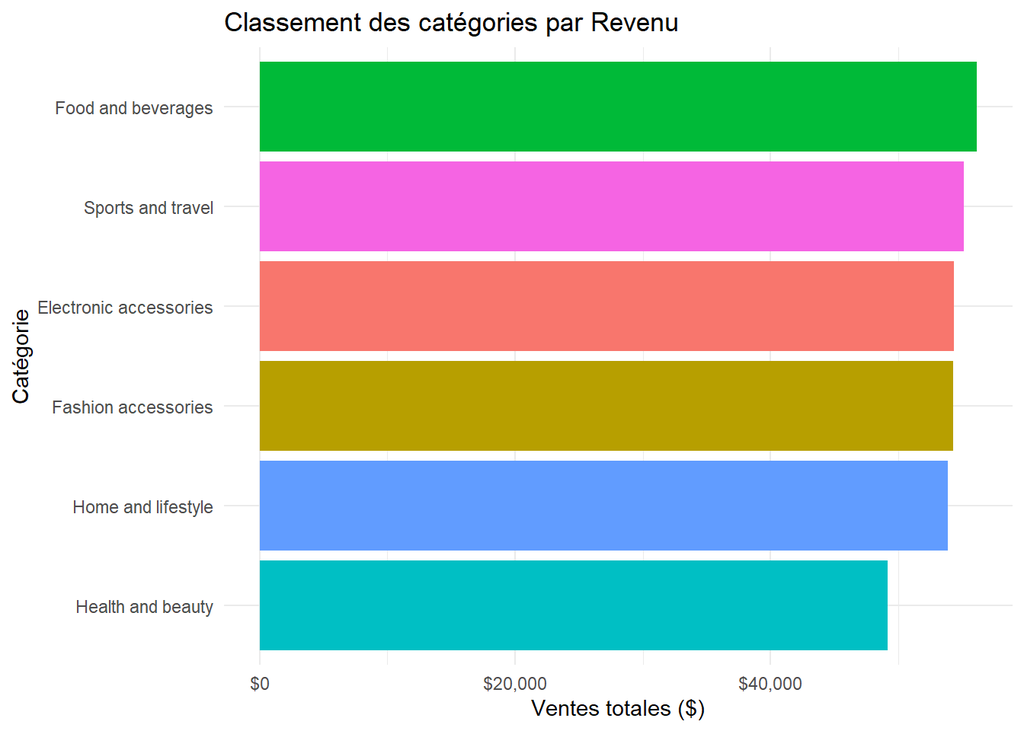

```r
ggplot(product_sales, aes(x = reorder(`Product line`, Revenu_Total), y = Revenu_Total, fill = `Product line`)) +
  geom_col() +
  coord_flip() +
  scale_y_continuous(labels = label_dollar()) +
  labs(
    title = "Classement des catégories par Revenu",
    x = "Catégorie",
    y = "Ventes totales ($)"
  ) +
  theme_minimal() +
  guides(fill = "none")
```

# 4. ANALYSE DES TENDANCES TEMPORELLES

Est-ce que l’activité commerciale est influencée par le calendrier hebdomadaire ?

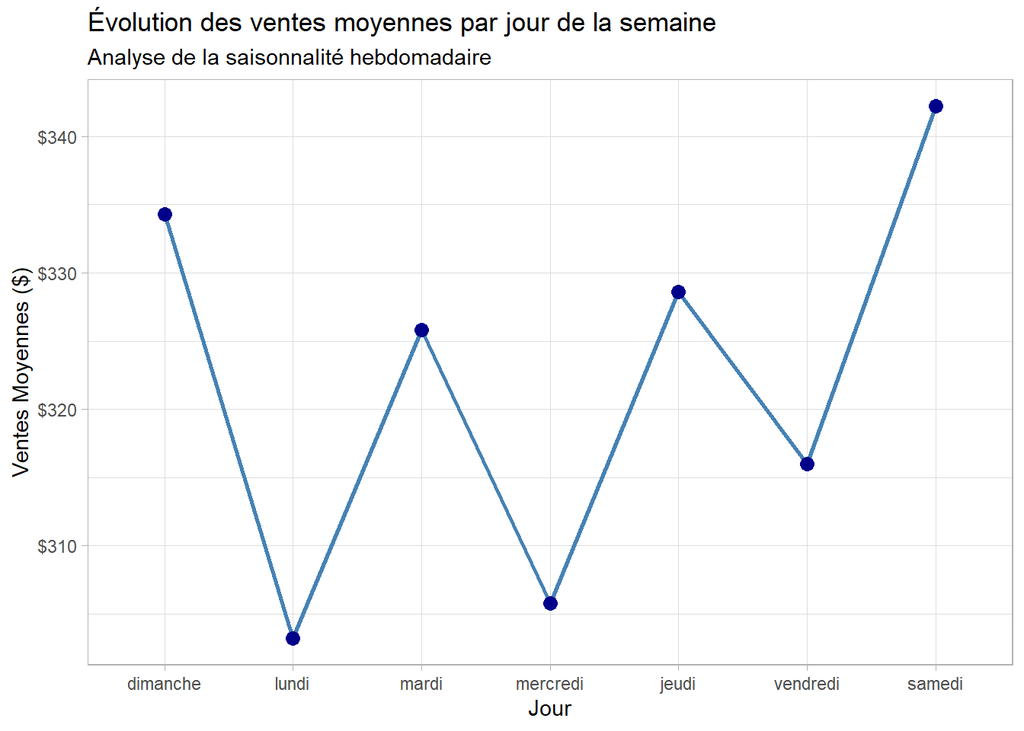

```r
sales_by_day <- df_clean %>%
  mutate(Jour = wday(Date, label = TRUE, abbr = FALSE)) %>%
  group_by(Jour) %>%
  summarise(Ventes_Moyennes = mean(Sales))

ggplot(sales_by_day, aes(x = Jour, y = Ventes_Moyennes, group = 1)) +
  geom_line(color = "steelblue", linewidth = 1) +
  geom_point(size = 3, color = "darkblue") +
  scale_y_continuous(labels = label_dollar()) +
  labs(title = "Évolution des ventes moyennes par jour de la semaine",
       subtitle = "Analyse de la saisonnalité hebdomadaire",
       y = "Ventes Moyennes ($)") +
  theme_light()
```